# Estimación del Coeficiente de Gini para Colombia mediante Algoritmo Iterativo de Densidad Kernel con Datos Agrupados.

Aplicación práctica con la dase de datos de Medición de Pobreza Monetaria y Desigualdad 2024 del DANE

Lubin Fernando Abaunza Melo

20 de Noviembre

# Artículo

[figure not shown]

$$\\$$

### Introducción

- El artículo propone una metodología **no paramétrica** para estimar indicadores de pobreza y desigualdad a partir de **datos de ingresos agrupados**.
- El problema surge porque muchas encuestas, como el Microcenso Alemán, no recogen los ingresos exactos, sino intervalos
- Esto impide aplicar las fórmulas estadísticas estándar.
- La solución es un **algoritmo iterativo de densidad kernel (KDE)** que genera pseudo-muestras métricas a partir de los grupos.

### 1. Tasade de incidencia de la pobreza (HCR)

$\\$

$$\widehat{I}_{HCR} =
\frac{1}{\sum_{i=1}^{n} w_i}
\sum_{i=1}^{n} w_i \, \mathbb{I}({X}_i \le z),$$

donde:

- $z$: línea de pobreza,
- ${X}_i$: ingreso ,
- $w_i$: peso muestral.

$\\$

El HCR es una medida del porcentaje de observaciones (individuos u hogares) por debajo de la línea de pobreza

### 2. Brecha de pobreza (PGap)

$\\$

$$\widehat{I}_{\text{PGAP}} =
\frac{1}{\sum_{i=1}^{n} w_i}
\sum_{i=1}^{n}
w_i \left( \frac{z - \tilde{X}_i}{z} \right)
\mathbf{1}(\tilde{X}_i \leq z),$$

donde:

- $z$: línea de pobreza,
- ${X}_i$: ingreso ,
- $w_i$: peso muestral.

$\\$

El Poverty Gap (PGap) mide la brecha promedio entre el ingreso de los hogares pobres y la línea de pobreza, expresada como proporción de dicha línea. Esto refleja cuán lejos, en promedio, están los pobres de superar la pobreza.

$\\$

### 3. Índice de Gini

$\\$

$$\widehat{I}_{\text{Gini}} =
\frac{2\sum_{i=1}^{n} w_i \tilde{X}_i \sum_{j=1}^{i} w_j -
\sum_{i=1}^{n} w_i^2 \tilde{X}_i}
{(\sum_{i=1}^{n} w_i)(\sum_{i=1}^{n} w_i \tilde{X}_i)} - 1.$$

$\\$

El coeficiente de Gini toma valores en el intervalo $[0, 1]$, donde:

- $0$ representa **igualdad perfecta**(todos los individuos poseen el mismo ingreso)
- $1$ representa **desigualdad máxima** (un solo individuo concentra todos le ingreso)

$\\$

## Algoritmo KDE

$\\$ **Paso 1 – Inicialización**

Usar los puntos medios de los intervalos como valores iniciales $\tilde{X}_i^{(0)}$.

A partir de ellos, estimar una densidad preliminar $\hat{f}_h^{(0)}(x)$ mediante KDE con un kernel gaussiano.

$$\hat{f}_k^{(0)}(x) = \frac{1}{n h} \sum_{i=1}^n K\!\left( \frac{x -
\tilde{X}_i^{(0)}}{h} \right),$$

El ancho de banda inicial $h_0$ se recomienda igual al doble del ancho del intervalo más grande.

$\\$

**Paso 2 – Construcción de la malla de evaluación:**

Definir una malla de puntos $G = \{g_1, g_2, \ldots, g_j\}$ que cubra el rango total de la variable:

$$\delta_g = \frac{|A_0 - A_{n_K}|}{j - 1}, \quad
G = \{ g_1 = A_0, \, g_2 = A_0 + \delta_g, \, \ldots, \, g_j = A_{n_K}
\}.$$

$\\$

**Paso 3 – Generación de pseudo-muestras:**

Para cada grupo $K$, generar una pseudo-muestra $\tilde{X}_i$ dentro del intervalo $(A_{K-1}, A_K]$ con probabilidad proporcional a la densidad estimada:

$$P(\tilde{X}_i = g_j) \propto \hat{f}_h(g_j), \quad g_j \in (A_{K-1},
A_K].$$

$\\$

**Paso 4 – Cálculo de los indicadores:**

Usar la pseudo-muestra $\tilde{X}_i$ para calcular los indicadores deseados.(por ejemplo, HCR,PGap , Gini).

$\\$

**Paso 5 - Actualización de la densidad**

Reestimar la densidad $\hat{f}_h(x)$ aplicando nuevamente KDE sobre la pseudo-muestra.

El ancho de banda $h$ puede calcularse mediante el método plug-in (minimiza el error cuadrático medio integrado (MISE)).

$\\$

**Paso 6 - Iteración**

Repetir los pasos 3–5 durante un número total de iteraciones $B_{\text{KDE}} + S_{\text{KDE}}$, donde $B_{\text{KDE}}$ son iteraciones de *burn-in}* (descartadas) y $S_{\text{KDE}}$ son las iteraciones de estimación final.

En el artículo, se emplean $B_{\text{KDE}} = 80$ y $S_{\text{KDE}} = 400$.

$\\$

**Paso 7 - Promediado final**

El valor final de cada indicador se obtiene como el promedio de las estimaciones de las $S_{\text{KDE}}$ iteraciones posteriores al burn-in:

$$\hat{I} = \frac{1}{S_{\text{KDE}}} \sum_{s=1}^{S_{\text{KDE}}}
\hat{I}^{(s)}.$$

$\\$

## variabilidad

Fuentes de variabilidad del estimador

1. **Variabilidad interna del algoritmo KDE:** debida al carácter estocástico del muestreo condicional en las pseudo-muestras $\tilde{X}_i$.
2. **Variabilidad del muestreo original:** derivada de que los datos provienen de una muestra.

Por ello, la varianza final del estimador no puede obtenerse solo de las iteraciones internas del algoritmo.

El artículo propone un **bootstrap no paramétrico externo** para la estimación de la varianza de los indicadores por el algoritmo KDE.

**Paso 1**

Se extrae una muestra con reemplazo de los datos agrupados originales:

$$X_i^{*}, \quad i = 1, \ldots,
n.$$

**Paso 2:**

A la muestra $X_i^{*}$ se le aplica **todo el algoritmo KDE** (es decir, pasos 1 - 7), obteniendo una estimación:$\hat{I}^{*}$

**Paso 3:**

Repetir el parso ($1-2$) $B$ veses, el **error estándar bootstrap** se calcula como:

$$\hat{se}(\hat{I}) = \sqrt{\frac{1}{B-1} \sum_{b=1}^{B} \left(
\hat{I}^{*(b)} - \overline{I}^{*} \right)^2}, \quad \text{donde } ~~
\overline{I}^{*} = \frac{1}{B} \sum_{b=1}^{B} \hat{I}^{*}(b).$$

$\\$

## Conclusiones del artículo

- El algoritmo **KDE** supera a los métodos tradicionales utilizados por las oficinas estadísticas (Uni y Mid) en términos de menor sesgo en todos los escenarios evaluados.
- Produce resultados prácticamente insesgados bajo distintos tipos de censura y diferentes distribuciones teóricas subyacentes.
- El sesgo relativo aumenta ligeramente cuando disminuye el número de grupos, pero aun así:
  - Incluso con censura extrema (solo 8 grupos), el algoritmo mantiene alta precisión.
  - El sesgo relativo permanece por debajo del 1% para casi todos los indicadores.
- En términos de precisión, el algoritmo **KDE** obtiene resultados comparables a la estimación directa basada en datos continuos no agrupados.
- Frente a los métodos Uni y Mid, el **KDE** muestra mayor precisión en la mayoría de los indicadores evaluados.

# Valor agregado

$\\$ $\\$

“Ningún método estadístico es universalmente el mejor.  
La elección depende de los datos, la pregunta y el contexto.”  
— *Peter McCullagh*

$$\\$$

### Linea de pobreza

| **Método** | **En qué consiste** | **Dónde se usa** | **Ventajas** | **Desventajas** |
| --- | --- | --- | --- | --- |
| **Línea de pobreza relativa** | Mide pobreza respecto a los estándares sociales actuales. Típicamente es el **50% o 60% de la mediana del ingreso**. | Países de la **Unión Europea** (Eurostat usa 60% de la mediana), **Reino Unido**, **Australia**, y organismos como la **OECD**. | - Captura desigualdad relativa. - Se ajusta automáticamente a cambios económicos. - Mide exclusión social y estándares de vida. | - No mide carencias absolutas. - No representa “necesidades básicas”. |
| **Línea de pobreza por Costo de Canasta Básica (CB–LP)** *(Método usado por el DANE)* | Refleja el costo monetario de satisfacer necesidades básicas. | Usado en **América Latina**: México (CONEVAL), Chile, Perú, Argentina (INDEC). En Colombia lo calcula el **DANE** con la metodología oficial del Banco Mundial. | - Refleja necesidades reales de consumo. - No depende de cambios relativos en salarios/ingresos | - Requiere estudios complejos de canastas y precios. - Puede quedarse rezagado frente a cambios sociales. - No captura pobreza relativa o exclusión social. |

$$\\$$

#### Paquete *smicd* desarrollado por los autores

- Los autores implementan su metodología en el paquete de R *smicd*.
- El paquete está diseñado para trabajar con datos agrupados o censurados por intervalos.
- Facilita la aplicación práctica del algoritmo propuesto en el artículo.

$$\\$$

¿Qué hace el paquete *smicd*?

Implementa un **algoritmo de densidad kernel** para reconstruir la distribución del ingreso a partir de datos agrupados por intervalo.

Calcula:

- Media, mediana, cuantiles
- Coeficiente de Gini
- HCR (Tasade de incidencia de la pobreza)
- PGAP (Brecha de pobreza )

**Utiliza la línea de pobreza relativa**

$$\\$$
$$\\$$

Función *kdeAlgo* para la aplicación empírica del algoritmo:

```
kdeAlgo(
  xclass = datos_ingresos,
  classes = limites_clase,
  threshold = 0.6,
  burnin = 80,
  samples = 400,
  bootstrap.se = TRUE,
  b = 100,
  bw = "nrd0",
  evalpoints = 4000,
  upper = 3,
  weights = NULL
)
```

### 1. Medición de Pobreza Monetaria y Desigualdad 2024 del DANE

$$\\$$

[figure not shown]

$$\\$$

La Medición de Pobreza Monetaria y Desigualdad 2024 (EMP 2024) es una operación estadística del Departamento Administrativo Nacional de Estadística (DANE), cuyo propósito es estimar los principales indicadores de pobreza monetaria, pobreza extrema y desigualdad de ingresos a nivel nacional, por dominio rural/urbano y para las 23 principales ciudades y áreas metropolitanas.

En la edición 2024, se obtuvo información de 275.057 hogares en todo el país, a los cuales se les midieron las siguientes variables de interés.

| **Variable** | **Descripción** | **Categorías / Valor** |
| --- | --- | --- |
| **p5090** | Tenencia de la vivienda | 1. Propia pagada 2. Propia en pago 3. Arriendo / Subarriendo 4. Usufructo 5. Posesión sin título 6. Propiedad colectiva 7. Otra |
| **p5100** | Pago mensual por cuota de amortización | Valor en pesos |
| **p5130** | Arriendo imputado (estimado si tuviera que pagarse) | Valor en pesos |
| **nper** | Número de personas en el hogar | Conteo |
| **ingtotug** | Ingreso total (sin imputación de arriendo) | Valor monetario |
| **ingtotarr** | Ingreso total (con imputación de arriendo) | Valor monetario |
| **ingpcug** | Ingreso per cápita (con imputación de arriendo) | Valor monetario |
| **li** | Línea de indigencia | Valor monetario |
| **lp** | Línea de pobreza | Valor monetario |
| **fex_c** | Factor de expansión anualizado | Factor |
| **fex_dpto** | Factor de expansión departamental | Factor |
| **dpto** | Departamento | Código DANE |
| **clase** | Tipo de área geográfica del hogar | 1. Cabecera (urbano) 2. Resto (rural) |

La variable que se considerará es **ingpcug:** Ingreso per cápita (con imputación de arriendo).

$$\\$$

### 2. Agrupamiento por intervalos

Los intervalos de ingreso considerados para la construcción de las clases fueron los siguientes:

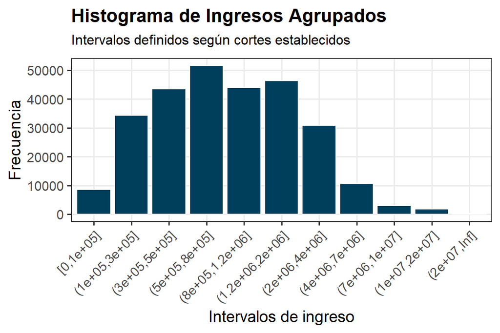

$$\\$$

### 3. Aplicacion del algoritmo

```
library(smicd)
library(dplyr)

Hogares <- read.csv("Hogares.csv")
limites_gr <- c(0, 100000, 300000, 500000, 800000, 1200000,
               2000000, 4000000, 7000000, 10000000,
               20000000, Inf)

Hogares <- Hogares %>%
  mutate(
    xclass = cut(ingpcug, breaks = limites_gr))


resultado_nacional <- kdeAlgo(
  xclass = Hogares$xclass,
  classes = limites_gr,
  weights = Hogares$fex_c,
  threshold = 0.6,
  burnin = 80,
  samples = 400,
  bootstrap.se = TRUE,
  b = 100,
  bw = "nrd0",
  evalpoints = 2000,
  upper = 3
)
```

$$\\$$

### Análisis Nacional

$$\\$$

| **Indicador** | **Nacional** | **Cabecera** | **Resto** | **Unidad de Medida** |
| --- | --- | --- | --- | --- |
| **Coeficiente de Gini** | 0.568 | 0.546 | 0.523 |  |
| **Percentil 10 (P10)** | 200100.0 | 250125.0 | 100050.0 | Pesos |
| **Percentil 25 (P25)** | 400200.1 | 500250.1 | 200100.0 | Pesos |
| **Media de ingresos** | 1412611.9 | 1637142.4 | 598486.8 | Pesos |
| **Mediana (P50)** | 750375.2 | 950475.2 | 354927.5 | Pesos |
| **Percentil 75 (P75)** | 1550775.4 | 1800900.4 | 695222.6 | Pesos |
| **Percentil 90 (P90)** | 2997748.9 | 3492496.2 | 1230990.5 | Pesos |

$$\\$$
$$\\$$

### Convergencia

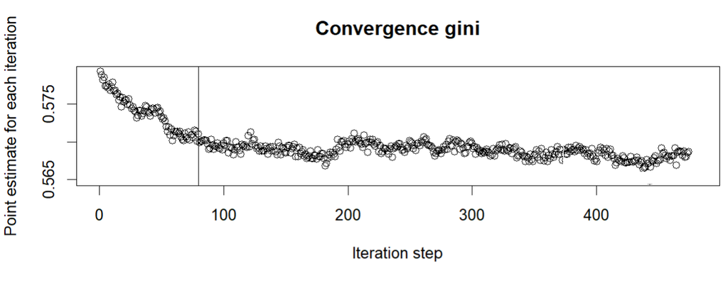

### Análisis Departamental

$$\\$$

**Indice de gini**

$$\\$$

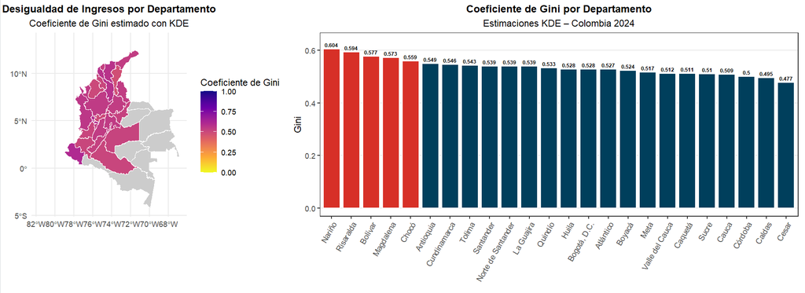

$$\\$$
**Cuantil 10 de Ingreso per cápita (con imputación de arriendo)**

$$\\$$

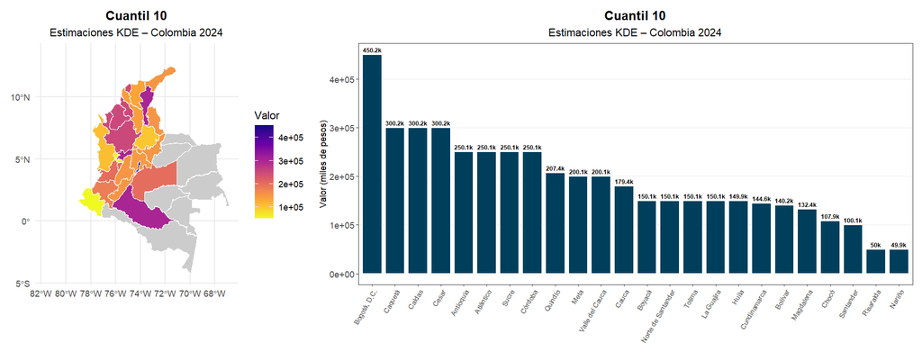

$$\\$$
**Cuantil 25 de Ingreso per cápita (con imputación de arriendo)**
$$\\$$

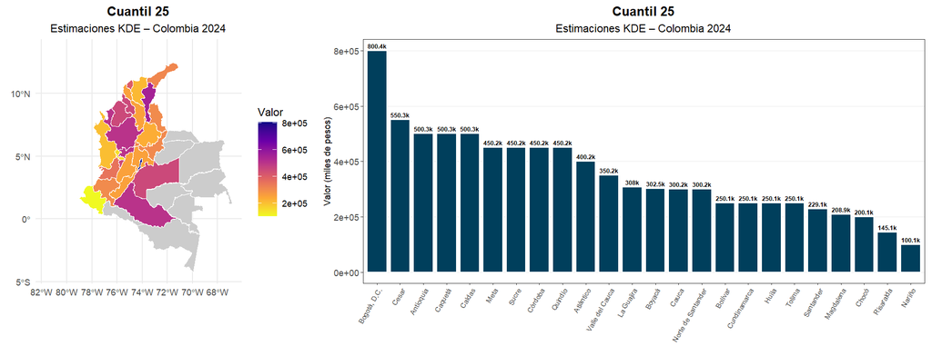

$$\\$$
**Cuantil 50 de Ingreso per cápita (con imputación de arriendo)**

$$\\$$

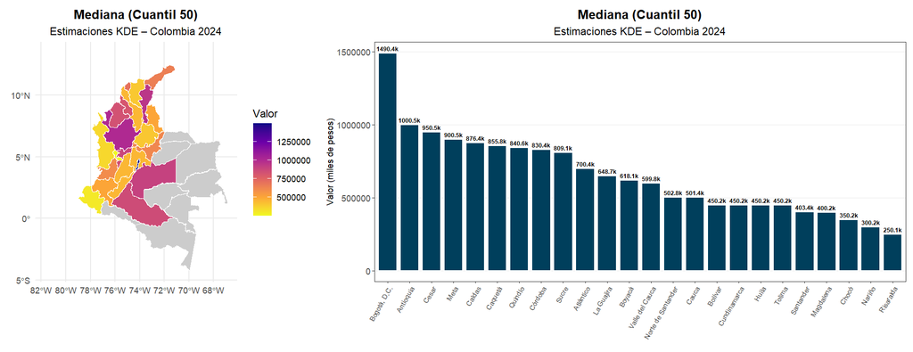

$$\\$$
**Cuantil 75 de Ingreso per cápita (con imputación de arriendo)**

$$\\$$

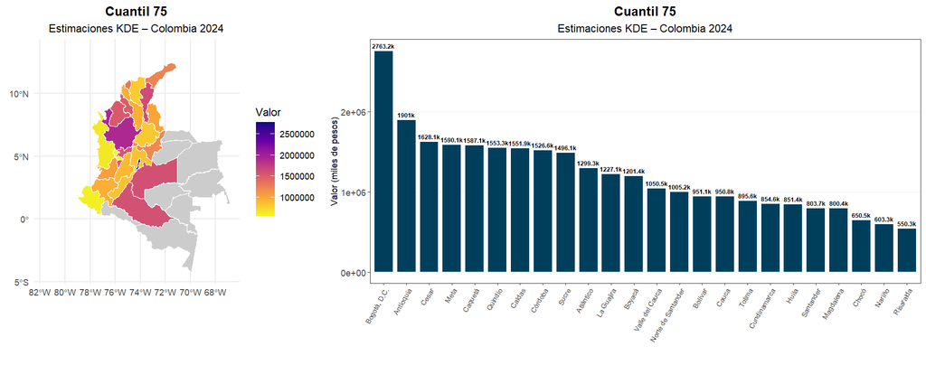

$$\\$$
**Cuantil 90 de Ingreso per cápita (con imputación de arriendo)**

$$\\$$

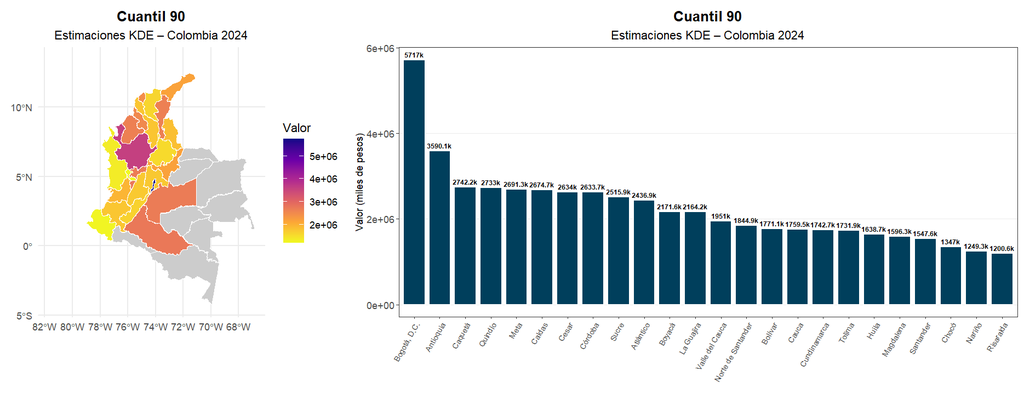

$$\\$$

# Bibliografia

- Walter, P., Gro$B$, M., Schmid, T. y Weimer, K. (2022). *Iterative Kernel Density Estimation Applied to Grouped Data: Estimating Poverty and Inequality Indicators from the German Microcensus*.Journal of Official Statistics, 38(2), 599–635.doi: 10.2478/JOS-2022-0027
- Giraldo, R. (2025). Estadística No Paramétrica: Alternativas a Pruebas Clásicas, Estimación de la Densidad y Análisis de Regresión. Ilustraciones con R. Departamento de Estadística, Universidad Nacional de Colombia, Sede Bogot´a. Disponible en: https://sites.google.com/ a/unal.edu.co/ramon-giraldo-webpage/
- Departamento Administrativo Nacional de Estadística (DANE). DSO-EMP-FME-001_F_V2: Documento técnico de la operación estadística de pobreza monetaria. Disponible en: https://www.dane.gov.co/files/operaciones/PM/DSO-EMP-FME-001_F_V2.pdf